# ProsperLoan Dataset Exploration

## by Volker Felvic Katche Tachin

## Investigation Overview

> The goal of this investigation is to look at the relationship between features like employment status, loan term, and Income Range on Borrower Rate

## Dataset Overview

> This data set contains 113,937 loans with 81 variables on each loan, including loan amount, borrower rate (or interest rate), current loan status, borrower income, and many others.

> An overview of the data features can be found at (https://docs.google.com/spreadsheets/d/1gDyi_L4UvIrLTEC6Wri5nbaMmkGmLQBk-Yx3z0XDEtI/edit#gid=0)

## Borrower Rate Distribution

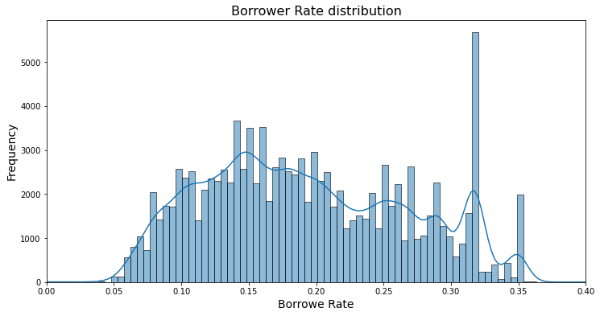

## How does Income range affect borrower rate

> It is evident that the highest income groups have the lowest borrower rates, which calls for further investigation

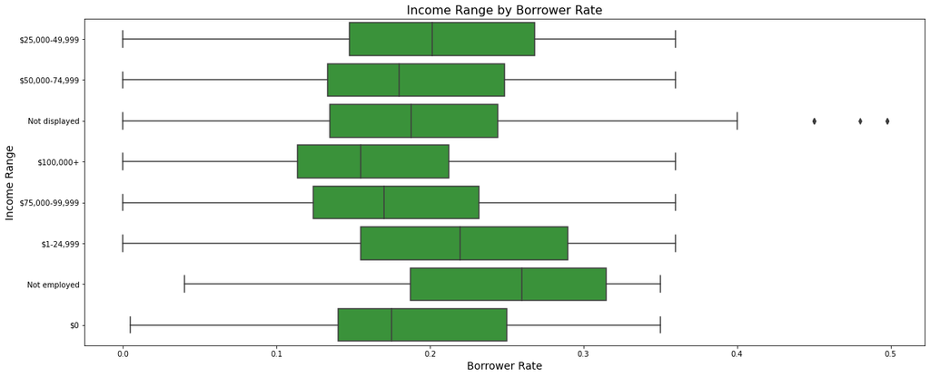

## What is the relationship between employment status, loan term and borrower rate

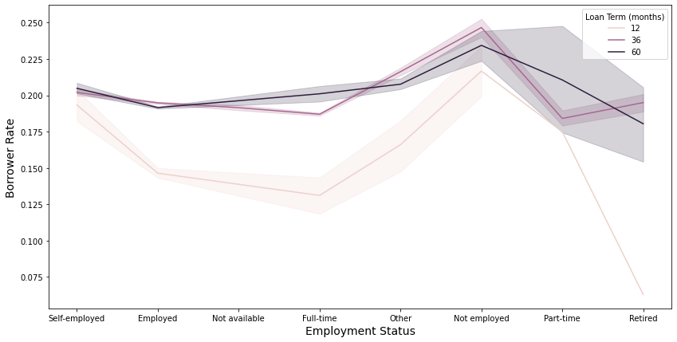